# xwMOOC 모형 - `tidymodels`

`parsnip` + `tidytext` + `textrecipes`

[Tidyverse Korea](https://www.facebook.com/groups/tidyverse/)

Tidyverse Korea

2020-08-08

# 1 텍스트 저자 분류[^1][^2]

고전작가 중 제인 오스틴 ’오만과 편견’과 유사한 길이를 갖는 코난 도일의 ’셜록 홈즈의 모험’을 구텐베르그 웹사이트에서 가져와서 작가를 판별하는 예측모형을 구축해본다.

**[한국인이 가장 사랑하는 세계적인 작가는? - 현존 작가 베르나르 베르베르, 고전작가 생텍쥐페리](http://www.econovill.com/news/articleView.html?idxno=219074)**

‘불멸의 고전 작가’ 투표에서는 ‘어린 왕자’의 앙투안 드 생텍쥐페리가 5,513표(7%)를 얻어 최고의 영예를 안았다. ’셜록 홈즈’ 시리즈의 아서 코난 도일은 4,366표(5.6%)로 2위, ’레 미제라블’의 빅토르 위고는 4,266표(5.4%)로 3위를 차지했다. 이어 헤르만 헤세가 5.4%로 4위에 올랐고, 윌리엄 셰익스피어(5.3%), 어니스트 헤밍웨이(5.1%), 제인 오스틴(4.7%), 조지 오웰(3.9%) 등이 5~8위로 뒤를 이었다.

# 2 데이터 가져오기

구텐베르그에 모든 고전 영문소설이 공개된 것은 아니다. 따라서 몇분정도 유명한 서양작가의 소설을 찾아 코난 도일과 제인 오스틴의 소설을 대표로 다운로드 받아 이를 분류하는 모형을 개발해 본다.

```r
library(tidyverse)
library(tidymodels)
library(tidytext)

## 텍스트 데이터
library(gutenbergr)

titles <- c(
  "Pride and Prejudice",
  "The Adventures of Sherlock Holmes")

books <- gutenberg_works(title %in% titles) %>%
  gutenberg_download(meta_fields = "title") %>%
  mutate(title = as.factor(title)) %>%
  select(-gutenberg_id)

books %>%
  count(title)
```

```
# A tibble: 2 x 2
  title                                 n
  <fct>                             <int>
1 Pride and Prejudice               13030
2 The Adventures of Sherlock Holmes 12648
```

# 3 훈련/시험 데이터 쪼개기[^3]

`rsample` 팩키지 `initial_split()` 함수로 훈련/시험 데이터를 7:3으로 쪼갠다.

```r
books_split <- initial_split(books,
                             strata = "title",
                             p = 0.70)

train_df <- training(books_split)
test_df <- testing(books_split)
```

# 4 피처 공학(feature engineering)

```r
library(textrecipes)
library(stopwords)

title_rec <- recipe(title ~ ., data = train_df) %>%
  step_filter(text != "") %>%
  step_tokenize(text) %>%
  step_ngram(text, num_tokens = 2, min_num_tokens = 1) %>%
  step_tokenfilter(text,  max_tokens = 250) %>%
  step_tfidf(text)

title_rec %>% prep() %>% juice()
```

```
# A tibble: 14,545 x 251
   title tfidf_text_a tfidf_text_a_ve… tfidf_text_about tfidf_text_after
   <fct>        <dbl>            <dbl>            <dbl>            <dbl>
 1 Prid…        0                    0                0                0
 2 Prid…        0                    0                0                0
 3 Prid…        0.401                0                0                0
 4 Prid…        0.361                0                0                0
 5 Prid…        0.201                0                0                0
 6 Prid…        0                    0                0                0
 7 Prid…        0                    0                0                0
 8 Prid…        0                    0                0                0
 9 Prid…        0                    0                0                0
10 Prid…        0                    0                0                0
# … with 14,535 more rows, and 246 more variables: tfidf_text_again <dbl>,
#   tfidf_text_all <dbl>, tfidf_text_all_the <dbl>, tfidf_text_always <dbl>,
#   tfidf_text_am <dbl>, tfidf_text_an <dbl>, tfidf_text_and <dbl>,
#   tfidf_text_and_a <dbl>, tfidf_text_and_i <dbl>, tfidf_text_and_the <dbl>,
#   tfidf_text_any <dbl>, tfidf_text_anything <dbl>, tfidf_text_are <dbl>,
#   tfidf_text_as <dbl>, tfidf_text_as_i <dbl>, tfidf_text_as_to <dbl>,
#   tfidf_text_at <dbl>, tfidf_text_at_the <dbl>, tfidf_text_away <dbl>,
#   tfidf_text_back <dbl>, tfidf_text_be <dbl>, tfidf_text_been <dbl>,
#   tfidf_text_before <dbl>, tfidf_text_being <dbl>, tfidf_text_bennet <dbl>,
#   tfidf_text_bingley <dbl>, tfidf_text_but <dbl>, tfidf_text_but_i <dbl>,
#   tfidf_text_by <dbl>, tfidf_text_by_the <dbl>, tfidf_text_came <dbl>,
#   tfidf_text_can <dbl>, tfidf_text_cannot <dbl>, tfidf_text_case <dbl>,
#   tfidf_text_collins <dbl>, tfidf_text_come <dbl>, tfidf_text_could <dbl>,
#   tfidf_text_could_not <dbl>, tfidf_text_darcy <dbl>, tfidf_text_day <dbl>,
#   tfidf_text_dear <dbl>, tfidf_text_did <dbl>, tfidf_text_did_not <dbl>,
#   tfidf_text_do <dbl>, tfidf_text_do_not <dbl>, tfidf_text_done <dbl>,
#   tfidf_text_door <dbl>, tfidf_text_down <dbl>, tfidf_text_elizabeth <dbl>,
#   tfidf_text_enough <dbl>, tfidf_text_ever <dbl>, tfidf_text_every <dbl>,
#   tfidf_text_face <dbl>, tfidf_text_family <dbl>, tfidf_text_father <dbl>,
#   tfidf_text_first <dbl>, tfidf_text_for <dbl>, tfidf_text_for_the <dbl>,
#   tfidf_text_found <dbl>, tfidf_text_friend <dbl>, tfidf_text_from <dbl>,
#   tfidf_text_from_the <dbl>, tfidf_text_give <dbl>, tfidf_text_go <dbl>,
#   tfidf_text_good <dbl>, tfidf_text_great <dbl>, tfidf_text_had <dbl>,
#   tfidf_text_had_been <dbl>, tfidf_text_has <dbl>, tfidf_text_have <dbl>,
#   tfidf_text_have_been <dbl>, tfidf_text_having <dbl>, tfidf_text_he <dbl>,
#   tfidf_text_he_had <dbl>, tfidf_text_he_was <dbl>, tfidf_text_heard <dbl>,
#   tfidf_text_her <dbl>, tfidf_text_here <dbl>, tfidf_text_herself <dbl>,
#   tfidf_text_him <dbl>, tfidf_text_himself <dbl>, tfidf_text_his <dbl>,
#   tfidf_text_holmes <dbl>, tfidf_text_hope <dbl>, tfidf_text_house <dbl>,
#   tfidf_text_how <dbl>, tfidf_text_however <dbl>, tfidf_text_i <dbl>,
#   tfidf_text_i_am <dbl>, tfidf_text_i_had <dbl>, tfidf_text_i_have <dbl>,
#   tfidf_text_i_shall <dbl>, tfidf_text_i_should <dbl>,
#   tfidf_text_i_was <dbl>, tfidf_text_if <dbl>, tfidf_text_in <dbl>,
#   tfidf_text_in_a <dbl>, tfidf_text_in_his <dbl>, tfidf_text_in_the <dbl>,
#   tfidf_text_indeed <dbl>, …
```

# 5 모형 선정

`XGBoost` 예측모형을 저작 분류문제를 해결하는데 사용할 수 도 있는데, 텍스트 데이터에 기반하여 분류기를 제작할 경우 다음 모형이 상대적으로 컴퓨팅 자원도 적게 소모하면서 더 좋은 성능을 보여준다. 이유는 Basetable 모형행렬이 매우 성긴 구조를 갖기 때문에 다음 모형이 XGBoost, Random Forest 와 같은 나무모형보다 권장된다.

- `glmnet`: Regularized linear models
- SVM: Support vector machines
- 나이브 베이즈: naive Bayes

```r
lasso_spec <- logistic_reg(penalty = tune(), mixture = 1) %>%
  set_mode("classification") %>%
  set_engine("glmnet")
lasso_spec
```

```
Logistic Regression Model Specification (classification)

Main Arguments:
  penalty = tune()
  mixture = 1

Computational engine: glmnet
```

## 5.1 CV & 초모수 격자탐색

`glmnet` Lasso 회귀모형을 적합시킬 때 초모수(hyper paramter) 하나를 특정해야한다. 이를 위해서 다음과 같이 격자탐색기를 특정하고 이를 교차검증표본(Cross Validation)으로 초모수를 특정한다.

```r
param_grid <- grid_regular(
  penalty(range = c(-4, 0)),
  levels = 10
)
param_grid
```

```
# A tibble: 10 x 1
    penalty
      <dbl>
 1 0.0001
 2 0.000278
 3 0.000774
 4 0.00215
 5 0.00599
 6 0.0167
 7 0.0464
 8 0.129
 9 0.359
10 1
```

초모수 특정을 위해서 빵과 버터, 김치와 밥처럼 함께 따라다니는 것이 교차검증표본(Cross Validation)이다. `vfold_cv()` 함수를 가장 많이 사용한다.

```r
title_folds <- vfold_cv(train_df, strata = title)
title_folds
```

```
#  10-fold cross-validation using stratification
# A tibble: 10 x 2
   splits               id
   <list>               <chr>
 1 <split [16.2K/1.8K]> Fold01
 2 <split [16.2K/1.8K]> Fold02
 3 <split [16.2K/1.8K]> Fold03
 4 <split [16.2K/1.8K]> Fold04
 5 <split [16.2K/1.8K]> Fold05
 6 <split [16.2K/1.8K]> Fold06
 7 <split [16.2K/1.8K]> Fold07
 8 <split [16.2K/1.8K]> Fold08
 9 <split [16.2K/1.8K]> Fold09
10 <split [16.2K/1.8K]> Fold10
```

# 6 작업흐름(workflow)

`workflow()`를 통해 앞서 훈련/시험 분리, 전처리, 예측모형, 모형 공식 등을 모듈화시킨 것을 한곳으로 연결시켜 자동화한다.

```r
title_wf <- workflow() %>%
  add_recipe(title_rec) %>%
  add_model(lasso_spec)

title_wf
```

```
══ Workflow ═════════════════════════════════════════════════════════════════════════════════════════
Preprocessor: Recipe
Model: logistic_reg()

── Preprocessor ─────────────────────────────────────────────────────────────────────────────────────
5 Recipe Steps

● step_filter()
● step_tokenize()
● step_ngram()
● step_tokenfilter()
● step_tfidf()

── Model ────────────────────────────────────────────────────────────────────────────────────────────
Logistic Regression Model Specification (classification)

Main Arguments:
  penalty = tune()
  mixture = 1

Computational engine: glmnet
```

## 6.1 초모수 특정

`glmnet` 모형에서 특정되지 않는 `penalty =`를 CV로 튜닝하여 최적 초모수를 잡아낸다.

```r
library(tictoc)

tic()
doParallel::registerDoParallel() #윈도우에서 오류가 생김

lasso_rs <- tune_grid(
  title_wf,
  resamples = title_folds,
  grid = param_grid,
  control = control_grid(save_pred = TRUE, verbose = TRUE)
)
toc()
```

```
23.686 sec elapsed
```

```r
lasso_rs %>%
  write_rds("data/lasso_rs.rds")
```

# 7 모형 평가

2020-08-08 현재 윈도우10에서 돌릴 경우 여러 문제가 생기기 때문에 가능하면 맥이나 리눅스에서 직접 돌리는 것이 문제의 본질에 집중할 수 있을 것으로 보인다. 맥에서 돌린 모형 결과를 윈도우에서 가져와서 나머지 작업을 이어서 한다.

```r
lasso_rs <- read_rds("data/lasso_rs.rds")
lasso_rs %>%
  collect_metrics()
```

```
# A tibble: 20 x 7
    penalty .metric  .estimator  mean     n   std_err .config
      <dbl> <chr>    <chr>      <dbl> <int>     <dbl> <chr>
 1 0.0001   accuracy binary     0.689    10 0.00411   Model01
 2 0.0001   roc_auc  binary     0.790    10 0.00433   Model01
 3 0.000278 accuracy binary     0.689    10 0.00404   Model02
 4 0.000278 roc_auc  binary     0.790    10 0.00438   Model02
 5 0.000774 accuracy binary     0.692    10 0.00415   Model03
 6 0.000774 roc_auc  binary     0.791    10 0.00448   Model03
 7 0.00215  accuracy binary     0.695    10 0.00504   Model04
 8 0.00215  roc_auc  binary     0.791    10 0.00476   Model04
 9 0.00599  accuracy binary     0.687    10 0.00416   Model05
10 0.00599  roc_auc  binary     0.786    10 0.00470   Model05
11 0.0167   accuracy binary     0.671    10 0.00592   Model06
12 0.0167   roc_auc  binary     0.763    10 0.00452   Model06
13 0.0464   accuracy binary     0.602    10 0.00505   Model07
14 0.0464   roc_auc  binary     0.677    10 0.00569   Model07
15 0.129    accuracy binary     0.507    10 0.0000429 Model08
16 0.129    roc_auc  binary     0.5      10 0         Model08
17 0.359    accuracy binary     0.507    10 0.0000429 Model09
18 0.359    roc_auc  binary     0.5      10 0         Model09
19 1        accuracy binary     0.507    10 0.0000429 Model10
20 1        roc_auc  binary     0.5      10 0         Model10
```

## 7.1 라소모형 시각화

`autoplot()` 혹은 `select_best()` 함수를 사용해서 초모수 튜닝 결과를 다음 후속 모형평가와 예측에 사용할 수 있다.

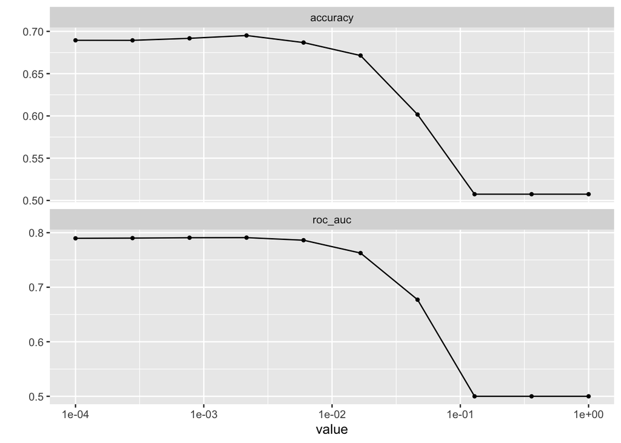

```r
lasso_rs %>%
  autoplot()
```

## 7.2 ROC 시각화

ROC 곡선을 그려 모형 성능에 대한 시각화 작업을 수행한다.

```r
best_roc_auc <- select_best(lasso_rs, "roc_auc")
best_roc_auc
```

```
# A tibble: 1 x 2
  penalty .config
    <dbl> <chr>
1 0.00215 Model04
```

`collect_predictions()` 함수는 앞선 예측값에 더하여 ROC 곡선생성에 필요한 확률값도 함께 포함하고 있다. 이를 입력값으로 삼아 `roc_curve()`를 그릴 수 있다.

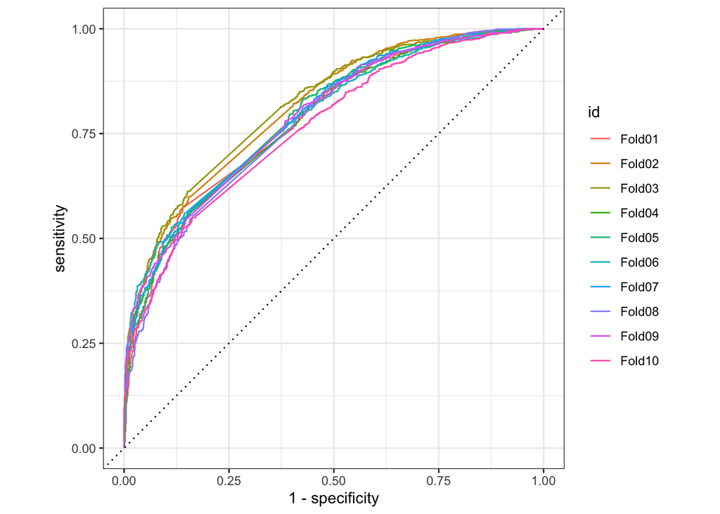

```r
collect_predictions(lasso_rs, parameters = best_roc_auc) %>%
  group_by(id) %>%
  roc_curve(truth = title, `.pred_Pride and Prejudice`) %>%
  autoplot()
```

예측모형 성능에 대한 주요 측도를 뽑아본다.

```r
collect_predictions(lasso_rs, parameters = best_roc_auc) %>%
  conf_mat(truth = title, `.pred_class`) %>%
  summary() %>%
  select(-.estimator) %>%
  filter(.metric %in% c("accuracy", "precision", "recall", "f_meas"))
```

```
# A tibble: 4 x 2
  .metric   .estimate
  <chr>         <dbl>
1 accuracy      0.695
2 precision     0.685
3 recall        0.738
4 f_meas        0.711
```

`roc_curve()`와 `autoplot()`을 쭉 연결시켜 시각화를 빠르게 수행한다.

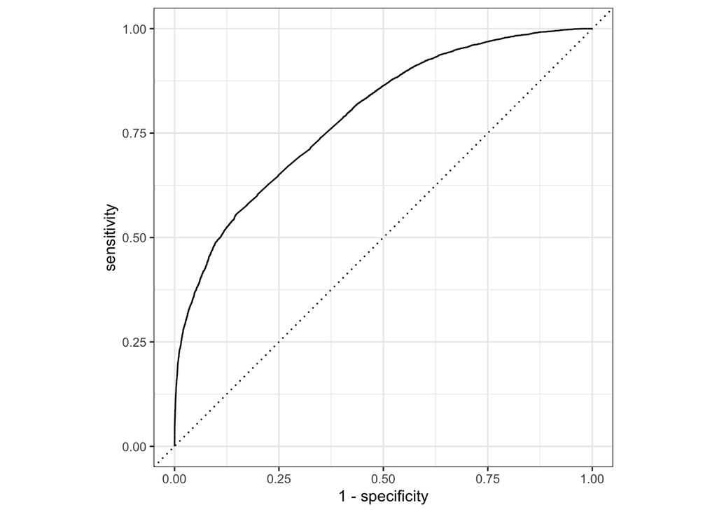

```r
collect_predictions(lasso_rs, parameters = best_roc_auc) %>%
  roc_curve(title, `.pred_Pride and Prejudice`) %>%
  autoplot()
```

# 8 변수 중요도

`title_wf`에 초모수 튜닝 결과를 반영시켜 최종 작업흐름을 완성한다. 이를 위해서 사용되는 함수가 `finalize_workflow()`다.

```r
wf_spec_final <- finalize_workflow(title_wf, best_roc_auc)
wf_spec_final
```

```
══ Workflow ═════════════════════════════════════════════════════════════════════════════════════════
Preprocessor: Recipe
Model: logistic_reg()

── Preprocessor ─────────────────────────────────────────────────────────────────────────────────────
5 Recipe Steps

● step_filter()
● step_tokenize()
● step_ngram()
● step_tokenfilter()
● step_tfidf()

── Model ────────────────────────────────────────────────────────────────────────────────────────────
Logistic Regression Model Specification (classification)

Main Arguments:
  penalty = 0.00215443469003188
  mixture = 1

Computational engine: glmnet
```

`vip` 팩키지를 동원해서 변수중요도를 추출하는데 먼저 데이터프레임을 준비한다.

```r
library(vip)

vi_data <- wf_spec_final %>%
  fit(train_df) %>%
  pull_workflow_fit() %>%
  vi(lambda = best_roc_auc$penalty) %>%
  mutate(Variable = str_remove_all(Variable, "tfidf_text_")) %>%
  filter(Importance != 0)

vi_data
```

```
# A tibble: 248 x 3
   Variable Importance Sign
   <chr>         <dbl> <chr>
 1 holmes        19.6  POS
 2 upon_the       3.19 POS
 3 i_am           2.79 POS
 4 to_me          2.44 POS
 5 upon           2.40 POS
 6 face           2.28 POS
 7 i              2.16 POS
 8 said_he        2.03 POS
 9 down           1.93 POS
10 we             1.81 POS
# … with 238 more rows
```

오만과 편견(Pride and Prejudice), 셜록홈즈의 모험(The Adventures of Sherlock Holmes)으로 분류하는데 큰 영향을 주는 변수를 상위 20개만 뽑아 시각화해서 서로 비교해보자.

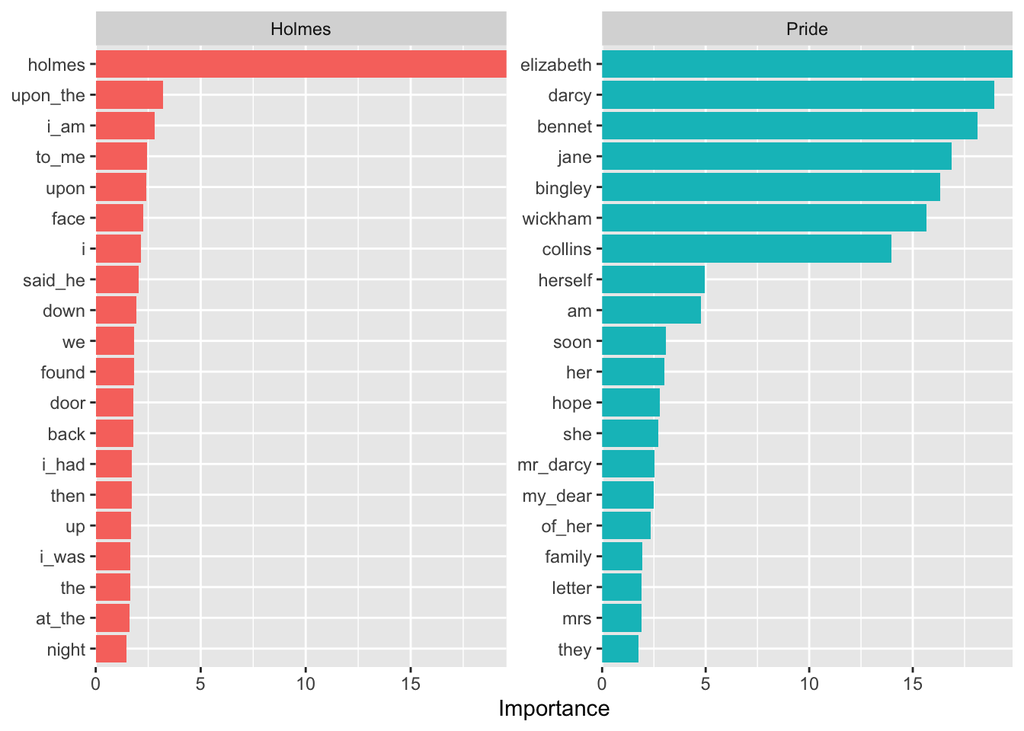

```r
vi_data %>%
  mutate( Importance = abs(Importance)) %>%
  filter(Importance != 0) %>%
  group_by(Sign) %>%
  top_n(20, Importance) %>%
  ungroup() %>%
  mutate(Sign = factor(Sign, c("POS", "NEG"), c("Holmes", "Pride"))) %>%
  ggplot(aes(x = Importance,y = fct_reorder(Variable, Importance), fill = Sign)) +
    geom_col(show.legend = FALSE) +
    scale_x_continuous(expand = c(0, 0)) +
    facet_wrap(~Sign, scales = "free") +
    labs(y = NULL )
```

# 9 최종 모형 및 성능

이제 예측모형을 마지막 배포하기에 앞서 시험데이터(test data)를 통해서 최종 모형 성능화 예측모형을 완성시켜보자.

```r
final_fit <- last_fit(wf_spec_final, books_split)
final_fit
```

```
# Resampling results
# Monte Carlo cross-validation (0.7/0.3) with 1 resamples
# A tibble: 1 x 6
  splits        id          .metrics      .notes      .predictions     .workflow
  <list>        <chr>       <list>        <list>      <list>           <list>
1 <split [18K/… train/test… <tibble [2 ×… <tibble [0… <tibble [7,703 … <workflo…
```

초모수 튜닝까지 끝난 최종 모형에 대한 평가측도는 다음과 같다.

```r
final_fit %>%
  collect_metrics()
```

```
# A tibble: 2 x 3
  .metric  .estimator .estimate
  <chr>    <chr>          <dbl>
1 accuracy binary         0.695
2 roc_auc  binary         0.795
```

`collect_predicions()` 함수와 `roc_curve()` 함수를 사용해서 시각화하자.

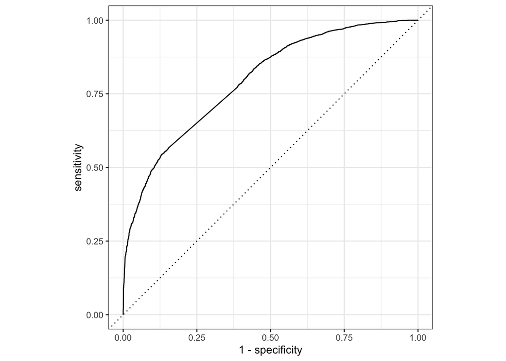

```r
final_fit %>%
  collect_predictions() %>%
  roc_curve(title, `.pred_Pride and Prejudice`) %>%
  autoplot()
```

[^1]: [EMIL HVITFELDT, “Authorship classification with tidymodels and textrecipes”](https://www.hvitfeldt.me/blog/authorship-classification-with-tidymodels-and-textrecipes/)
[^2]: [EMIL HVITFELDT, “Text Classification with Tidymodels”](https://www.hvitfeldt.me/blog/text-classification-with-tidymodels/)
[^3]: [Emil Hvitfeldt, Julia Silge (24 July 2020), “Predictive modeling with text using tidy data principles”, Materials for our useR! 2020](https://github.com/EmilHvitfeldt/useR2020-text-modeling-tutorial)

데이터 과학자 [이광춘](https://github.com/statkclee/) 저작

*kwangchun.lee.7@gmail.com*